# DNA Alteration & Pharmacological Response

# Data Upload and Inspection

```r
load("project_dataset.RData")

head(CCLE_MUT_CNA_AMP_DEL_binary_Revealer[,1:4])
```

|  | DMS53_LUNG | SW1116_LARGE_INTESTINE | NCIH1694_LUNG | P3HR1_HAEMATOPOIETIC_AND_LYMPHOID_TISSUE |
| --- | --- | --- | --- | --- |
| AKT3_MUT | 0 | 0 | 0 | 0 |
| ABI1_MUT | 0 | 0 | 0 | 0 |
| CDH2_MUT | 0 | 0 | 0 | 0 |
| LOC100130776_MUT | 0 | 0 | 0 | 0 |
| HDAC6_MUT | 0 | 0 | 0 | 0 |
| BCL2L11_MUT | 0 | 0 | 0 | 0 |

```r
target <- target_data_NAcount_August21
row.names(target) <- as.character(target[,1])
target <- target[,-1]
head(target[,1:4])
```

|  | X22RV1_PROSTATE | X2313287_STOMACH | X42MGBA_CENTRAL_NERVOUS_SYSTEM | X451LU_SKIN |
| --- | --- | --- | --- | --- |
| (5Z)-7-Oxozeaenol | 0.8625642 | 0.7597489 | 0.6585792 | 0.1044209 |
| 5-Fluorouracil | 0.4865437 | 0.6063343 | 0.7244520 | 0.9585177 |
| 681640 | 0.9579365 | 0.9682534 | 0.9476494 | NaN |
| A-443654 | NaN | NaN | NaN | NaN |
| A-770041 | NaN | NaN | NaN | NaN |
| Afatinib (1) | 0.9808510 | 0.9815897 | 0.9844018 | 0.9888358 |

The **target_data_NAcount_August21** file contains the response of cell lines to various pharmacological compounds, from the GDSC project. Each row corresponds to a compound; each column corresponds to a cell line. The value of an entry is a measure of how much the cell line responds to the drug compound. More info about the project can be found here: https://www.cancerrxgene.org/

```r
library(readr)
pathways <- read_delim("PathwayCommons12.panther.hgnc.txt",
            "\t", escape_double = FALSE,
            col_types = cols(INTERACTION_DATA_SOURCE = col_skip(),
            INTERACTION_PUBMED_ID = col_skip(),
            INTERACTION_TYPE = col_skip(), MEDIATOR_IDS = col_skip(),
            PATHWAY_NAMES = col_skip()), trim_ws = TRUE)
head(pathways)
```

| PARTICIPANT_A | PARTICIPANT_B |
| --- | --- |
| ABAT | ALDH5A1 |
| ABAT | ALDH6A1 |
| ABAT | CSAD |
| ABAT | GAD1 |
| ABAT | GAD2 |
| ACHE | CHEBI:15354 |

The **PathwayCommons12.panther.hgnc** file contains all the gene-gene interactions discovered so far; this is useful in order to smooth the mutations matrix, which is extremely sparse. It has been downloaded from https://www.pathwaycommons.org/.

## Needed Packages

```r
suppressPackageStartupMessages({
conflictRules("DelayedArray", exclude = "seed")
library(NMF)
library(SummarizedExperiment)
library(netSmooth)
library(stringi)
library(stringr)
library(readr)
library(igraph)
library(tidyverse)
library(caret)
library(neuralnet)
library(plotly)
})
```

# Mutations Matrix Smoothing

The CCLE dataset sonsiders 48270 mutations: since the human genetic pool consists of around 20000 genes, and each one can mutate in three different ways (insertion, deletion, single-base mutation, the dataset is involving almost every possible mutation (20k*3 = 60k). It is necessary to select the most relevant mutations, because they exceed enourmously the number of cell lines, having a strong impact on future computations. The Non-Negative Matrix Factorization (NMF) is a powerful tool to perform feature selection, but it works well with non-sparse matrices.

The CCLE dataset appears to be extremely sparse, as it is possible to appreciate from the following heatmap. Even though the size has been reduced for computational reasons, the same situation can be extended to the whole set.

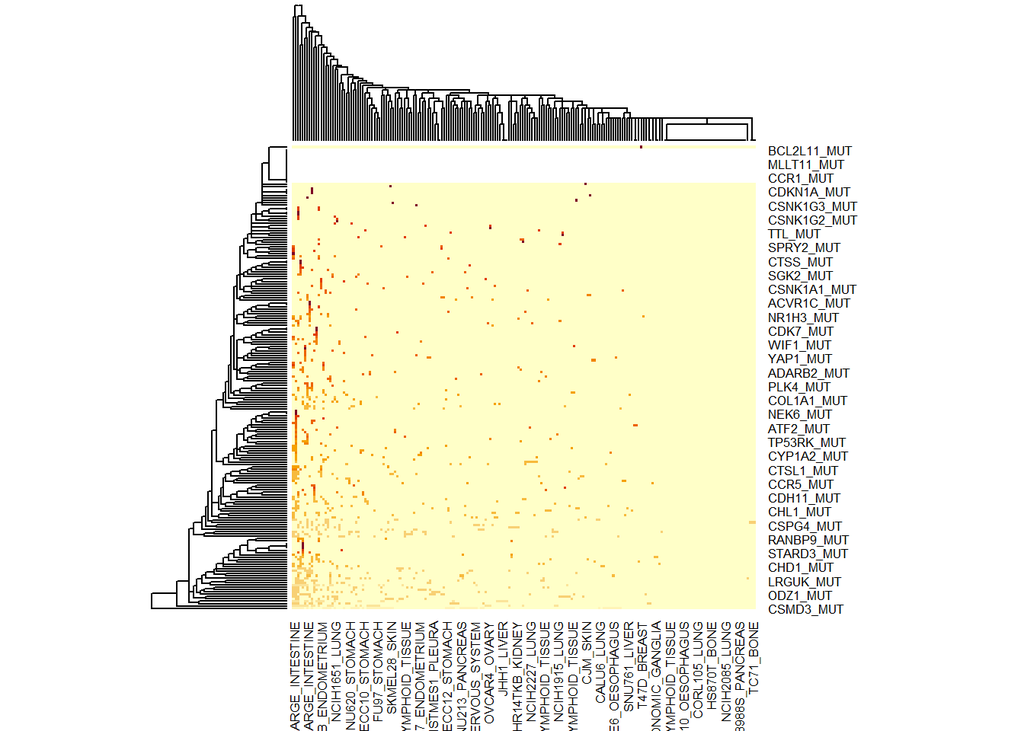

```r
heatmap(as.matrix(CCLE_MUT_CNA_AMP_DEL_binary_Revealer[1:200, 1:200]))
```

It may be useful to rename the matrices to make them more “user-friendly” to handle

```r
mutations <- CCLE_MUT_CNA_AMP_DEL_binary_Revealer
drugs <- target_data_NAcount_August21
```

It is important to work with comparable datasets, containing the same cell lines: this will enable robust results in terms of model construction. In the following lines of code, only common cell lines will be kept, filtering out the uncommon.

```r
tissues_CCLE <- colnames(mutations)
tissues_CCLE <- unique(gsub("[^_]*_(.*)", "\\1", tissues_CCLE))

tissues_GDSC <- colnames(drugs)[-1]
tissues_GDSC <- unique(gsub("[^_]*_(.*)", "\\1", tissues_GDSC))

# Which and how many different tissues are being considered?
(tissues <- sort(intersect(tissues_CCLE, tissues_GDSC)))
```

```
##  [1] "AUTONOMIC_GANGLIA"                  "BILIARY_TRACT"
##  [3] "BONE"                               "BREAST"
##  [5] "CENTRAL_NERVOUS_SYSTEM"             "ENDOMETRIUM"
##  [7] "HAEMATOPOIETIC_AND_LYMPHOID_TISSUE" "KIDNEY"
##  [9] "LARGE_INTESTINE"                    "LIVER"
## [11] "LUNG"                               "OESOPHAGUS"
## [13] "OVARY"                              "PANCREAS"
## [15] "PLEURA"                             "PROSTATE"
## [17] "SKIN"                               "SMALL_INTESTINE"
## [19] "SOFT_TISSUE"                        "STOMACH"
## [21] "THYROID"                            "UPPER_AERODIGESTIVE_TRACT"
## [23] "URINARY_TRACT"
```

```r
k <- length(tissues)

# Keeping only common cell lines
mutations <- mutations[, grep(paste(tissues, sep = "", collapse = "|"), colnames(mutations))]
drugs <- drugs[, grep(paste(tissues, sep = "", collapse = "|"), colnames(drugs))]
```

It is helpful to perform smoothing independently for mutations, insertions and deletions: the Pathway Commons interaction database considers gene-gene relationships and the smoothing algorithm (package *netSmooth*) recognizes the gene names in the dataset with respect to the adjacency matrix built on the interaction database itself. The following process is meant to separate the datasets into three smaller datasets, apply smoothing and then rebuild the original dataset, that now will include the non-sparse information.

```r
# Creation of the three datasets based on the type of mutation
mutations_MUT <- mutations[grep("_MUT", row.names(mutations)), ]
mutations_AMP <- mutations[grep("_AMP", row.names(mutations)), ]
mutations_DEL <- mutations[grep("_DEL", row.names(mutations)), ]

# Remove the subscripts from the lines of the matrices to be analyzed
row.names(mutations_MUT) <- str_replace_all(row.names(mutations_MUT), "_MUT", "")
row.names(mutations_AMP) <- str_replace_all(row.names(mutations_AMP), "_AMP", "")
row.names(mutations_DEL) <- str_replace_all(row.names(mutations_DEL), "_DEL", "")

# Creating the Adjacency Matrix
adj <- get.adjacency(graph.edgelist(as.matrix(pathways), directed=FALSE))

# Network smoothing
smoothed_MUT <- netSmooth(as.matrix(mutations_MUT), adj, alpha=0.5)
```

```
## Using given alpha: 0.5
```

```r
smoothed_AMP <- netSmooth(as.matrix(mutations_AMP), adj, alpha=0.5)
```

```
## Using given alpha: 0.5
```

```r
smoothed_DEL <- netSmooth(as.matrix(mutations_DEL), adj, alpha=0.5)
```

```
## Using given alpha: 0.5
```

```r
# Rebuild
row.names(smoothed_MUT) <- paste0(row.names(smoothed_MUT), "_MUT", "")
row.names(smoothed_DEL) <- paste0(row.names(smoothed_DEL), "_DEL", "")
row.names(smoothed_AMP) <- paste0(row.names(smoothed_AMP), "_AMP", "")
mutations.smoothed <- rbind(smoothed_MUT, smoothed_AMP, smoothed_DEL)

# If a mutation is not present in any cell line, you can remove it
# (it is also an NMF algorithm constraint)
mutations.smoothed <- mutations.smoothed[apply(mutations.smoothed, 1, function(x) !all(x==0)),]
```

# Cancer-targeted Feature Selection

The necessity of selecting the most relevant mutations has already been acknowledged. As a plus, it can improve the specificity of the analysis if each cancer type was considered independently. It should be worth focusing on tumors highly represented in terms of cell lines: also a “poorly-represented” cancer type will be included to check whether the lower amount of data affects the performance of the model. First of all, let’s check the number of cell lines per tumor.

```r
tissues_CCLE <- colnames(mutations.smoothed)
tissues_CCLE <- unique(gsub("[^_]*_(.*)", "\\1", tissues_CCLE))

tissues_occurrencies <- c()
for (i in 1:length(tissues_CCLE)) {
  tmp <- grep(tissues_CCLE[i], colnames(mutations.smoothed))
  tissues_occurrencies[i] <- length(tmp)
  rm(tmp)
}
tissues_occurrencies <- as.data.frame(t(tissues_occurrencies))
colnames(tissues_occurrencies) <- tissues_CCLE

# Sort tissues_occurrencies data frame column-wise
sorted_tissues_occurrencies <- tissues_occurrencies[, order(-apply(tissues_occurrencies, 2, sum))]

# Print the sorted data frame
print(sorted_tissues_occurrencies[1:5])
```

```
##   LUNG HAEMATOPOIETIC_AND_LYMPHOID_TISSUE CENTRAL_NERVOUS_SYSTEM SKIN
## 1  185                                182                     68   61
##   LARGE_INTESTINE
## 1              59
```

*Lung* and *Haematopoietic and Lymphoid Tissue* cancers will be included in the analysis; also *Breast* cancer will be considered, due to its clinical relevance, despite offering just one third of the data with respect to the other two cancer types.

In the following lines of code, the most relevant mutations for these three tumors will be extracted, once again through NMF and exploiting its built-in function featureScore(). The value **s** stands for the number of extracted mutations. **k** is the number of clusters.

```r
s <- 250
k<- 4

# LUNG --------------------------------------------------------------------

# Filtering out LUNG from data
mutations.smoothed_LUNG <- mutations.smoothed[, grep("_LUNG", colnames(mutations.smoothed))]
mutations.smoothed_LUNG <- mutations.smoothed_LUNG[apply(mutations.smoothed_LUNG, 1, function(x) !all(x==0)),]

# NMF
res_LUNG <- nmf(mutations.smoothed_LUNG, k, 'lee', seed=123456)
mutation_score_LUNG <- featureScore(res_LUNG)

# Feature selection
mutations_topscore_LUNG <- sort(featureScore(res_LUNG), decreasing = T)[1:s]

# Filter the mutations matrix based on scores
index <- c()
for (i in 1:length(mutations_topscore_LUNG)) {
  tmp <- grep(paste0("^", names(mutations_topscore_LUNG[i]), "$"), row.names(mutations))
  if(length(tmp)>1) cat(paste0(tmp, " "))
  index <- c(index, tmp)
}

mutations.filtered_LUNG <- mutations[index, grep("_LUNG", colnames(mutations))]


# HLT ---------------------------------------------------------------------

# Filtering out HLT from data
mutations.smoothed_HLT <- mutations.smoothed[, grep("_HAEMATOPOIETIC_AND_LYMPHOID_TISSUE", colnames(mutations.smoothed))]
mutations.smoothed_HLT <- mutations.smoothed_HLT[apply(mutations.smoothed_HLT, 1, function(x) !all(x==0)),]

# NMF
res_HLT <- nmf(mutations.smoothed_HLT, k, 'lee', seed=123456)
mutation_score_HLT <- featureScore(res_HLT)

# Feature selection
mutations_topscore_HLT <- sort(featureScore(res_HLT), decreasing = T)[1:s]

# Filter the mutations matrix based on scores
index <- c()
for (i in 1:length(mutations_topscore_HLT)) {
  tmp <- grep(paste0("^", names(mutations_topscore_HLT[i]), "$"), row.names(mutations))
  if(length(tmp)>1) cat(paste0(tmp, " "))
  index <- c(index, tmp)
}

mutations.filtered_HLT <- mutations[index, grep("_HAEMATOPOIETIC_AND_LYMPHOID_TISSUE", colnames(mutations))]


# BREAST ---------------------------------------------------------------------

# Filtering out BREAST from data
mutations.smoothed_BREAST <- mutations.smoothed[, grep("_BREAST", colnames(mutations.smoothed))]
mutations.smoothed_BREAST <- mutations.smoothed_BREAST[apply(mutations.smoothed_BREAST, 1, function(x) !all(x==0)),]

# NMF
res_BREAST <- nmf(mutations.smoothed_BREAST, k, 'lee', seed=123456)
mutation_score_BREAST <- featureScore(res_BREAST)

# Feature selection
mutations_topscore_BREAST <- sort(featureScore(res_BREAST), decreasing = T)[1:s]

# Filter the mutations matrix based on scores
index <- c()
for (i in 1:length(mutations_topscore_BREAST)) {
  tmp <- grep(paste0("^", names(mutations_topscore_BREAST[i]), "$"), row.names(mutations))
  if(length(tmp)>1) cat(paste0(tmp, " "))
  index <- c(index, tmp)
}

mutations.filtered_BREAST <- mutations[index, grep("_BREAST", colnames(mutations))]
```

# Final Data & Model Information

```r
mutations.filtered_BREAST[1:10,1:5]
```

|  | HCC2157_BREAST | HS739T_BREAST | HCC38_BREAST | DU4475_BREAST | MDAMB175VII_BREAST |
| --- | --- | --- | --- | --- | --- |
| PDCD6_AMP | 0 | 0 | 0 | 0 | 0 |
| EXOC3_AMP | 0 | 0 | 0 | 0 | 0 |
| C5orf55_AMP | 0 | 0 | 0 | 0 | 0 |
| PP7080_AMP | 0 | 0 | 0 | 0 | 0 |
| AHRR_AMP | 0 | 0 | 0 | 0 | 0 |
| SLC9A3_AMP | 0 | 0 | 0 | 0 | 0 |
| PLEKHG4B_AMP | 0 | 0 | 0 | 0 | 0 |
| LRRC14B_AMP | 0 | 0 | 0 | 0 | 0 |
| MIR4456_AMP | 0 | 0 | 0 | 0 | 0 |
| TPPP_AMP | 0 | 0 | 0 | 0 | 0 |

```r
sample(names(mutations_topscore_BREAST), 10)
```

```
##  [1] "DROSHA_AMP"    "LRRC14B_AMP"   "C5orf55_AMP"   "STIP1_DEL"
##  [5] "LOC340113_AMP" "MRPL49_DEL"    "L1TD1_DEL"     "TRABD2B_DEL"
##  [9] "TCEANC2_DEL"   "UBE2U_DEL"
```

Now that the mutation matrix has been reduced in size by considering both the most relevant mutations and the single cancer, it is possible to train and test a model able to predict the effect of a drug on a patient based on the cancer type and his mutational landscape.

## Lung Cancer Analysis

First thing is assemble the matrix for the model to be built on. One fundamental step is to consider only common cell lines, present both in the mutation and the target data.

```r
mutL <- mutations.filtered_LUNG

# Filtering out LUNG from data
targetL <- target[, grep("_LUNG", colnames(target))]

target.common <- targetL[, which(colnames(targetL) %in% colnames(mutL))]
mutations.common <- mutL[, which(colnames(mutL) %in% colnames(targetL))]
target.common <- t(target.common[, order(colnames(target.common))])
mutations.common <- t(mutations.common[, order(colnames(mutations.common))])

drug_names <- rownames(target)
```

The following step consists of creating a list of matrices, one for each single drug, having the *response variable y* to be predicted as the drug effectiveness. The mutation landscape for each cell line plays the role of *predictors*. For example…

```r
# Creating the matrices with the response y for the single drug
tm.list <- list()

for (i in 1:length(drug_names)) {
  tmp <- cbind(target.common[,i], mutations.common)
  colnames(tmp)[1] <- "drug"
  tmp <- tmp[-which(is.na(tmp[,1])), ] # remove cell lines with NaN on drug response
  tmp <- tmp[-which(rowSums(tmp[,-1]) == 0), ]
  tm.list[[i]] <- as.data.frame(tmp)
  rm(tmp)
}

names(tm.list) <- row.names(targetL)

tm.list[[1]][1:10,1:5]
```

|  | drug | ZNF197_DEL | ZNF501_DEL | TCAIM_DEL | ZNF660_DEL |
| --- | --- | --- | --- | --- | --- |
| ABC1_LUNG | 0.6937080 | 0 | 0 | 0 | 0 |
| BEN_LUNG | 0.9529593 | 1 | 1 | 1 | 1 |
| CALU3_LUNG | 0.8237809 | 0 | 0 | 0 | 0 |
| CHAGOK1_LUNG | 0.6811019 | 1 | 1 | 1 | 1 |
| COLO668_LUNG | 0.8997014 | 0 | 0 | 0 | 0 |
| CORL105_LUNG | 0.7064098 | 1 | 1 | 1 | 1 |
| CORL95_LUNG | 0.9313234 | 0 | 0 | 0 | 0 |
| CPCN_LUNG | 0.7310353 | 1 | 1 | 1 | 1 |
| DMS114_LUNG | 0.6837069 | 0 | 0 | 0 | 0 |
| DMS273_LUNG | 0.4735742 | 0 | 0 | 0 | 0 |

```r
#names(tm.list)[1]
```

The data are prepared as usual subdividing each matrix into training and test set.

```r
# Set the formula
f <- as.formula("drug ~ .")

# Prepare Training & Test set
train_frac <- 0.8
train_set <- list()
test_set <- list()
for (i in 1:length(drug_names)) {
  data <- tm.list[[i]]
  index <- sample(1:nrow(data), round(train_frac*nrow(data)))
  train_set[[i]] <- data[index,]
  test_set[[i]] <- data[-index,]
}
```

Two different model types are built and compared in terms of performance: a Generalized Linear Model and a Neural Network.

Let’s have a look at the GLM first. A simple cross-validation control is applied in order to obtain a model whose performance is realistic.

```r
MSE.glm_LUNG <- c()
glm.models_LUNG <-list()
response.glm_LUNG <- list()
for (i in 1:length(drug_names)) {
  train <- train_set[[i]]
  test <- test_set[[i]]

  glm.fit <- caret::train(form = f,
                          data      = train,
                          trControl = trainControl(method = "cv", number = 10),
                          method    = "glm",
                          family    = gaussian()
  )
  glm.models_LUNG[[i]] <- glm.fit
  pr.glm <- predict(glm.fit,test)
  response.glm_LUNG[[i]] <- pr.glm
  MSE.glm_LUNG[i] <- sum((pr.glm - test$drug)^2)/nrow(test)
}
names(MSE.glm_LUNG) <- drug_names
names(response.glm_LUNG) <- drug_names
```

The NN instead underwent a refinement processe. The number of hidden layers has always been kept to three, but the number of nodes has been selected after various attempts. First a simple model was chosen with a 5-5-5 layout, giving decent results; the high number of predictors may have suggested the use of a more complex model, such a 15-15-15 layout: the prediction error increased consistently. The model proposed below uses a 15-10-5 cascade-like layout, averaging the best performance error over the whole bunch of drugs analyzed.

```r
MSE.nn_LUNG <- c()
nn.models_LUNG <- list()
response.nn_LUNG <- list()
for (i in 1:length(drug_names)) {
  train <- train_set[[i]]
  test <- test_set[[i]]

  nn.fit <- caret::train(form = f,
                         data      = train,
                         trControl = trainControl(method = "none"),
                         method    = "neuralnet",
                         linear.output = TRUE,
                         tuneGrid = expand.grid(
                           layer1 = 15,
                           layer2 = 10,
                           layer3 = 5),
                         metric = "RMSE"
  )
  nn.models_LUNG[[i]] <- nn.fit
  pr.nn <- predict(nn.fit, test)
  response.nn_LUNG[[i]] <- pr.nn
  MSE.nn_LUNG[i] <- sum((pr.nn - test$drug)^2)/nrow(test)
}
names(MSE.nn_LUNG) <- drug_names
names(response.nn_LUNG) <- drug_names
```

Let’s compare the performance of these two different model approaches: the Neural Network seems to fit better the data, averaging a lower mean squared error.

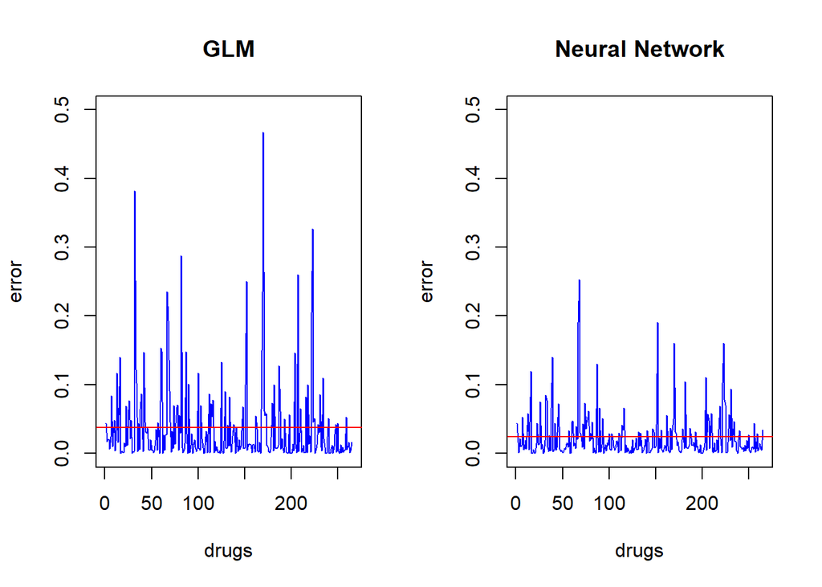

```r
#mean(MSE.glm_LUNG)
#mean(MSE.nn_LUNG)

par(mfrow=c(1,2))
plot(MSE.glm_LUNG, type="l", col="blue", main="GLM", ylim = c(0,0.5), xlab="drugs", ylab="error")
abline(h=mean(MSE.glm_LUNG), col="red")
plot(MSE.nn_LUNG, type="l", col="blue", main="Neural Network", ylim = c(0,0.5), xlab="drugs", ylab="error")
abline(h=mean(MSE.nn_LUNG), col="red")
```

And in a boxplot flavor…

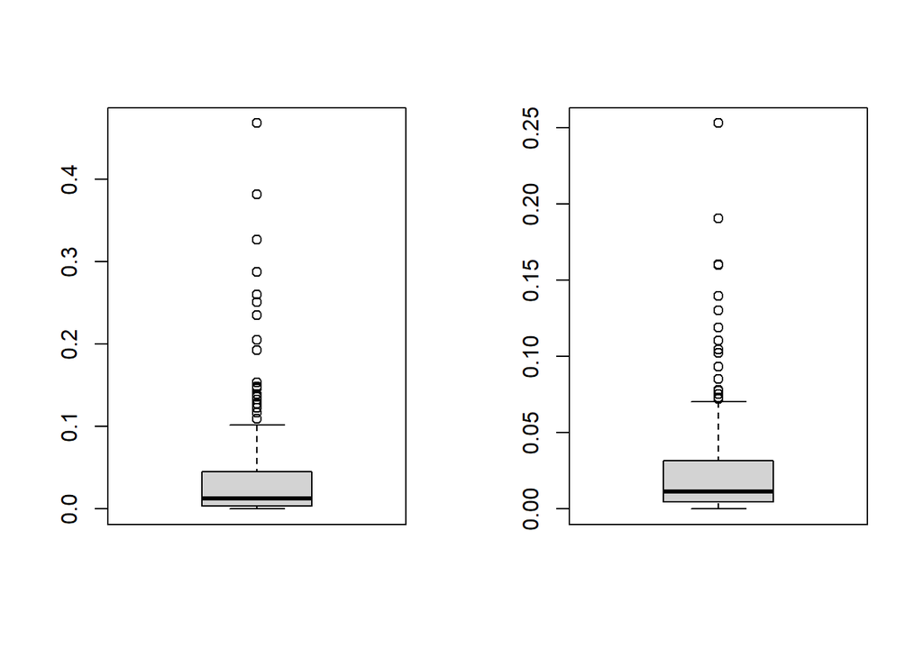

```r
par(mfrow=c(1,2))
boxplot(MSE.glm_LUNG)
boxplot(MSE.nn_LUNG)
```

## HLT Cancer Analysis

This and the next section will be just presented in terms of code: only the results will be discussed, as the algorithm being used is the same.

```r
mutH <- mutations.filtered_HLT

# Filtering out HLT from data
targetH <- target[, grep("_HAEMATOPOIETIC_AND_LYMPHOID_TISSUE", colnames(target))]

target.common <- targetH[, which(colnames(targetH) %in% colnames(mutH))]
mutations.common <- mutH[, which(colnames(mutH) %in% colnames(targetH))]
target.common <- t(target.common[, order(colnames(target.common))])
mutations.common <- t(mutations.common[, order(colnames(mutations.common))])

drug_names <- rownames(target)

# Creating the matrices with the response y for the single drug
tm.list <- list()

for (i in 1:length(drug_names)) {
  tmp <- cbind(target.common[,i], mutations.common)
  colnames(tmp)[1] <- "drug"
  tmp <- tmp[-which(is.na(tmp[,1])), ] # remove cell lines with NaN on drug response
  tmp <- tmp[-which(rowSums(tmp[,-1]) == 0), ]
  tm.list[[i]] <- as.data.frame(tmp)
  rm(tmp)
}

names(tm.list) <- row.names(targetH)

tm.list[[1]][1:10,1:5]
```

|  | drug | MIR1253_DEL | SMYD4_DEL | OVCA2_DEL | RTN4RL1_DEL |
| --- | --- | --- | --- | --- | --- |
| ALLSIL_HAEMATOPOIETIC_AND_LYMPHOID_TISSUE | 0.62925057 | 1 | 1 | 1 | 1 |
| AMO1_HAEMATOPOIETIC_AND_LYMPHOID_TISSUE | 0.69460228 | 0 | 0 | 0 | 0 |
| BL41_HAEMATOPOIETIC_AND_LYMPHOID_TISSUE | 0.62164778 | 1 | 1 | 1 | 1 |
| CMK_HAEMATOPOIETIC_AND_LYMPHOID_TISSUE | 0.66966436 | 1 | 1 | 1 | 1 |
| DEL_HAEMATOPOIETIC_AND_LYMPHOID_TISSUE | 0.75351781 | 0 | 0 | 0 | 0 |
| DND41_HAEMATOPOIETIC_AND_LYMPHOID_TISSUE | 0.58472259 | 0 | 0 | 0 | 0 |
| EM2_HAEMATOPOIETIC_AND_LYMPHOID_TISSUE | 0.60183747 | 1 | 1 | 1 | 1 |
| EOL1_HAEMATOPOIETIC_AND_LYMPHOID_TISSUE | 0.02374275 | 0 | 0 | 0 | 0 |
| GA10_HAEMATOPOIETIC_AND_LYMPHOID_TISSUE | 0.75515648 | 0 | 0 | 0 | 0 |
| GRANTA519_HAEMATOPOIETIC_AND_LYMPHOID_TISSUE | 0.79612871 | 1 | 1 | 1 | 1 |

```r
#names(tm.list)[1]
```

```r
f <- as.formula("drug ~ .")

# Training & Test set
train_frac <- 0.8
train_set <- list()
test_set <- list()
for (i in 1:length(drug_names)) {
  data <- tm.list[[i]]
  index <- sample(1:nrow(data), round(train_frac*nrow(data)))
  train_set[[i]] <- data[index,]
  test_set[[i]] <- data[-index,]
}

# GLM
MSE.glm_HLT <- c()
glm.models_HLT <-list()
response.glm_HLT <- list()
for (i in 1:length(drug_names)) {
  train <- train_set[[i]]
  test <- test_set[[i]]

  glm.fit <- caret::train(form = f,
                          data      = train,
                          trControl = trainControl(method = "cv", number = 10),
                          method    = "glm",
                          family    = gaussian()
  )
  glm.models_HLT[[i]] <- glm.fit
  pr.glm <- predict(glm.fit,test)
  response.glm_HLT[[i]] <- pr.glm
  MSE.glm_HLT[i] <- sum((pr.glm - test$drug)^2)/nrow(test)
}
names(MSE.glm_HLT) <- drug_names
names(response.glm_HLT) <- drug_names

# NN
MSE.nn_HLT <- c()
nn.models_HLT <- list()
response.nn_HLT <- list()
for (i in 1:length(drug_names)) {
  train <- train_set[[i]]
  test <- test_set[[i]]

  nn.fit <- caret::train(form = f,
                         data      = train,
                         trControl = trainControl(method = "none"),
                         method    = "neuralnet",
                         linear.output = TRUE,
                         tuneGrid = expand.grid(
                           layer1 = 15,
                           layer2 = 10,
                           layer3 = 5),
                         metric = "RMSE"
  )
  nn.models_HLT[[i]] <- nn.fit
  pr.nn <- predict(nn.fit, test)
  response.nn_HLT[[i]] <- pr.nn
  MSE.nn_HLT[i] <- sum((pr.nn - test$drug)^2)/nrow(test)
}
names(MSE.nn_HLT) <- drug_names
names(response.nn_HLT) <- drug_names
```

## Breast Cancer Analysis

```r
mutB <- mutations.filtered_BREAST

# Filtering out BREAST from data
targetB <- target[, grep("_BREAST", colnames(target))]

target.common <- targetB[, which(colnames(targetB) %in% colnames(mutB))]
mutations.common <- mutB[, which(colnames(mutB) %in% colnames(targetB))]
target.common <- t(target.common[, order(colnames(target.common))])
mutations.common <- t(mutations.common[, order(colnames(mutations.common))])

drug_names <- rownames(target)

# Creating the matrices with the response y for the single drug
tm.list <- list()

for (i in 1:length(drug_names)) {
  tmp <- cbind(target.common[,i], mutations.common)
  colnames(tmp)[1] <- "drug"
  tmp <- tmp[-which(is.na(tmp[,1])), ] # remove cell lines with NaN on drug response
  tmp <- tmp[-which(rowSums(tmp[,-1]) == 0), ]
  tm.list[[i]] <- as.data.frame(tmp)
  rm(tmp)
}

names(tm.list) <- row.names(targetB)

tm.list[[1]][1:10,1:5]
```

|  | drug | PDCD6_AMP | EXOC3_AMP | C5orf55_AMP | PP7080_AMP |
| --- | --- | --- | --- | --- | --- |
| BT20_BREAST | 0.7200960 | 1 | 1 | 1 | 1 |
| BT474_BREAST | 0.7017970 | 1 | 1 | 1 | 1 |
| CAL120_BREAST | 0.5741549 | 1 | 1 | 1 | 1 |
| CAL51_BREAST | 0.5353245 | 0 | 0 | 0 | 0 |
| CAL851_BREAST | 0.6662680 | 1 | 1 | 1 | 1 |
| CAMA1_BREAST | 0.8345755 | 0 | 0 | 0 | 0 |
| EFM19_BREAST | 0.7937339 | 0 | 0 | 0 | 0 |
| EFM192A_BREAST | 0.7805405 | 0 | 0 | 0 | 0 |
| EVSAT_BREAST | 0.7471169 | 0 | 0 | 0 | 0 |
| HCC1143_BREAST | 0.7371067 | 1 | 1 | 1 | 1 |

```r
#names(tm.list)[1]
```

```r
f <- as.formula("drug ~ .")

# Training & Test set
train_frac <- 0.8
train_set <- list()
test_set <- list()
for (i in 1:length(drug_names)) {
  data <- tm.list[[i]]
  index <- sample(1:nrow(data), round(train_frac*nrow(data)))
  train_set[[i]] <- data[index,]
  test_set[[i]] <- data[-index,]
}

# GLM
MSE.glm_BREAST <- c()
glm.models_BREAST <-list()
response.glm_BREAST <- list()
for (i in 1:length(drug_names)) {
  train <- train_set[[i]]
  test <- test_set[[i]]

  glm.fit <- caret::train(form = f,
                          data      = train,
                          trControl = trainControl(method = "cv", number = 10),
                          method    = "glm",
                          family    = gaussian()
  )
  glm.models_BREAST[[i]] <- glm.fit
  pr.glm <- predict(glm.fit,test)
  response.glm_BREAST[[i]] <- pr.glm
  MSE.glm_BREAST[i] <- sum((pr.glm - test$drug)^2)/nrow(test)
}
names(MSE.glm_BREAST) <- drug_names
names(response.glm_BREAST) <- drug_names

# NN
MSE.nn_BREAST <- c()
nn.models_BREAST <- list()
response.nn_BREAST <- list()
for (i in 1:length(drug_names)) {
  train <- train_set[[i]]
  test <- test_set[[i]]

  nn.fit <- caret::train(form = f,
                         data      = train,
                         trControl = trainControl(method = "none"),
                         method    = "neuralnet",
                         linear.output = TRUE,
                         tuneGrid = expand.grid(
                           layer1 = 15,
                           layer2 = 10,
                           layer3 = 5),
                         metric = "RMSE"
  )
  nn.models_BREAST[[i]] <- nn.fit
  pr.nn <- predict(nn.fit, test)
  response.nn_BREAST[[i]] <- pr.nn
  MSE.nn_BREAST[i] <- sum((pr.nn - test$drug)^2)/nrow(test)
}
names(MSE.nn_BREAST) <- drug_names
names(response.nn_BREAST) <- drug_names
```

## Results

It is worth comparing the performance of the models applied to the three selected cancer types.

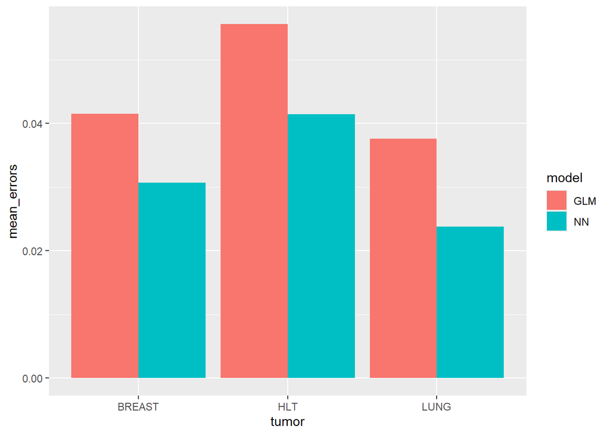

```r
mean_errors <- sapply(list(MSE.glm_LUNG, MSE.nn_LUNG, MSE.glm_HLT, MSE.nn_HLT, MSE.glm_BREAST, MSE.nn_BREAST), mean)

model <- rep(c("GLM", "NN"), 3)
tumor <- c(rep("LUNG", 2), rep("HLT", 2), rep("BREAST", 2))
performance <- data.frame(model, tumor, mean_errors)

ggplot(performance, aes(fill=model, y=mean_errors, x=tumor)) +
       geom_bar(position="dodge", stat="identity")
```